# Statistics 243, Final Project: An R Package for Multiple Factor Analysis

# Plotting Compromise/Common Factor Scores

The Compromise Factor Scores represent a compromise among the sub-tables regarding the coordinates of each object (row) along the components. The user can choose which components she or he wants to see. The defaults are components 1 and 2.

Default legend of this plot is rownames, which is mached to observation name. But we can set up legend as we want.

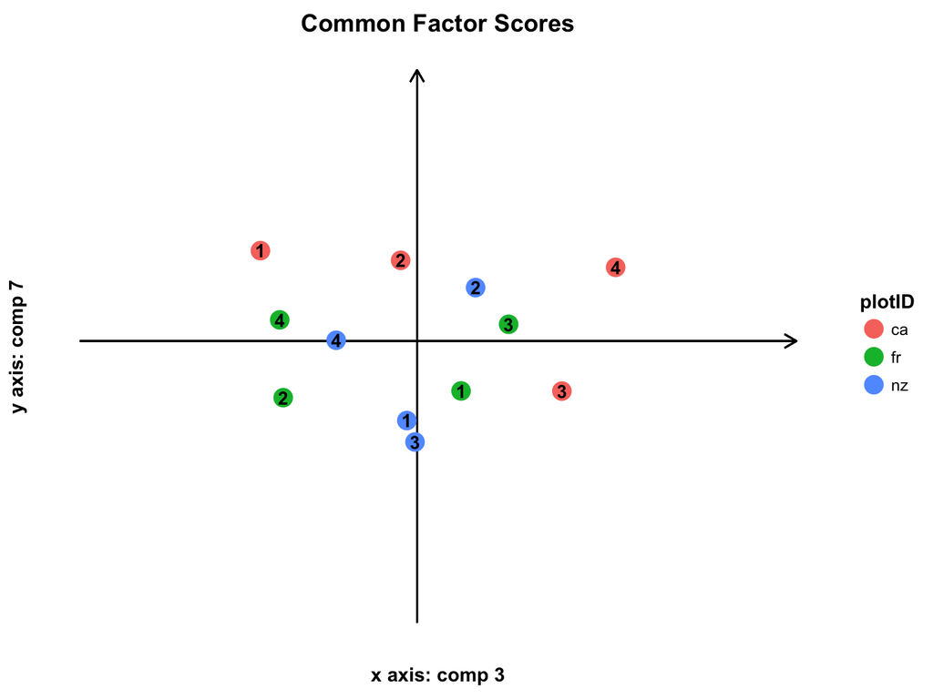

```r
plot(mfa1, type = "compromise", xdim = 3, ydim = 7, size = 5,
     legend=substr(rownames(mfa1$Fcommon),1,2), label=substr(rownames(mfa1$Fcommon),3,3),
     mytitle = "Common Factor Scores")
```

# Plotting Partial Factor Scores

The Partial Factor Scores plot lets us see where the objects fall along the component axes for each individual sub-table. The user can choose which sub-table(s) she/he wants to see with subtabs, legend and label.

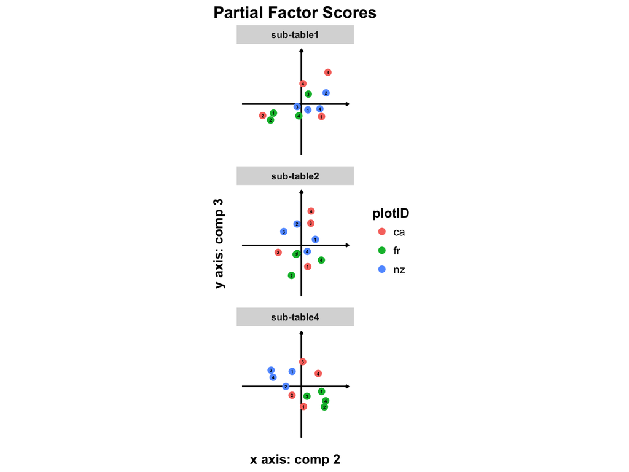

```r
plot(mfa1, type = "partial.factor", size = 2.5, subtabs = c(1,2,4),
     xdim = 2, ydim = 3, facetrows = 3,
     legend=substr(rownames(mfa1$Fpartial[[1]]),1,2), label=substr(rownames(mfa1$Fcommon),3,3))
```

# Plotting Compromise + Partial Factor Scores

Two plots, Compromise and Partial Factor scores can be combined in an one plot. Arguments xdim/ydim can be chosen by user. Also, label and legend can be applied on the plots.

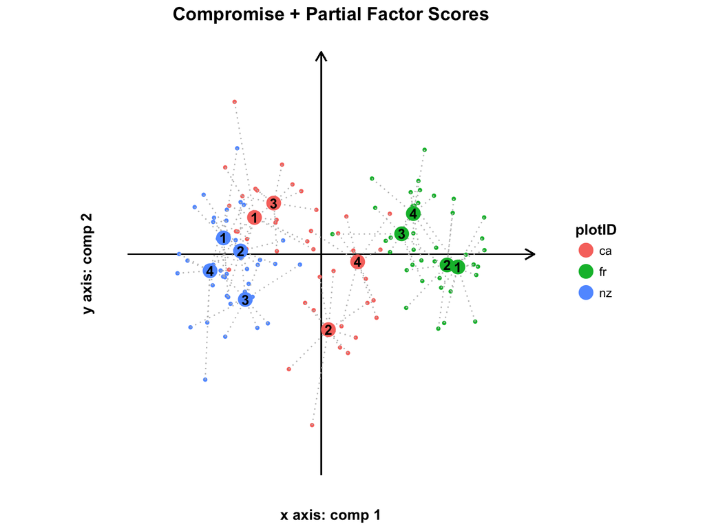

```r
plot(mfa1, type = "compromise.partial", xdim = 1, ydim = 2, size = 5,
     legend=substr(rownames(mfa1$Fcommon),1,2), label=substr(rownames(mfa1$Fcommon),3,3))
```

# Plotting Variable Loadings

Loadings are the right singular vectors from the Generalized Singular Value Decomposition. Users can write down the informative legend, with the optional `legend` paramter. To easily recognize the plots, choose sub-tables 9 and 10 only.

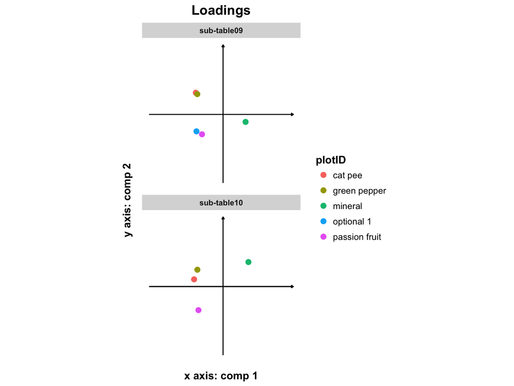

```r
plot(mfa1, type = "loadings", size = 2.5, subtabs = c(9,10),
     legend = c("cat pee", "passion fruit", "green pepper", "mineral",
                "optional 1", "optional 2"))
```

# eigsum()

```r
eigsum(x, verbose = FALSE)
```

This is a complementary method used to compute eigenvalues. It takes an mfa object and returns a table with the singular values, eigenvalues, cumulative, percentage of interia, and cummulative percentage of inertia for all the extracted components:

```r
summary <- eigsum(mfa1)
round(summary, 3)[,1:7]
```

```
##                        comp 1 comp 2 comp 3 comp 4 comp 5 comp 6 comp 7
## Singular Values         0.878  0.351  0.301  0.276  0.244  0.198  0.176
## Eigenvalues             0.770  0.123  0.091  0.076  0.060  0.039  0.031
## Cumulative Eigenvalues  0.770  0.893  0.984  1.060  1.120  1.159  1.190
## % Inertia              61.230  9.772  7.211  6.043  4.738  3.116  2.457
## Cumulative % Inertia   61.230 71.001 78.212 84.255 88.993 92.109 94.566
```

# Contributions

Contributions are descriptive statistics derived from the mfa object. They help tell us how the observations, variables, and tables contribute to the variability of the extracted dimensions.

### obscount()

The contribution of observation $i$ to component $l$, denoted $ctr_{i,l}$, is computed as

$ctr_{i,l} = \frac{m_i \times f^2_{i,l}}{\lambda_l}$

where $m_i$ is the mass of the $i$th observation, $f_{i,l}$ is the factor score of the $i$th observation for the $l$th dimension and $\lambda_l$ is the eigenvalue of the $l$th dimension.

### varcount()

The contribution of variable $j$ to component $l$, denoted $ctr_{j,l}$, is computed as

$ctr_{j,l} = a_j \times q^2_{j,l}$

where $a_j$ is the $\alpha$ weight for the $j$th variable, and $q_{i,l}$ is the loading of the $j$th variable for the $l$th dimension.

### tabcount()

Since a table comprimes of several variables, its contribution can just be defined as the sum of the contributions of its variables. The contribution of table $k$ to component $l$ is denoted $ctr_{k,l}$ and calculated as

$ctr_{k,l} = \sum\limits_{\textit{j}}^{\textit{J}_{[k]}} ctr_{j,l}$.

These three functions take an mfa object and return a matrix with the corresponding contribution values.

# Coefficients to study Between-Table Structure

### rv_coeff()

```r
rv_coeff(table1, table2)
```

To evaluate the similarity between two tables, we use the $\textit{R}_{\textit{V}}$ coefficient.

The $\textit{R}_{\textit{V}}$ coefficient varies between 0 and 1 and reflects the amount of variance shared by two matrices. The $\textit{R}_{\textit{V}}$ coefficient between data tables $k$ and $j$ is computed as

$\textit{R}_{\textit{V k,j}} = \frac{trace\{(\bf{X}_{[k]}\bf{X}^\intercal_{[k]}) \times (\bf{X}_{[j]}\bf{X}^\intercal_{[j]})\}}{\sqrt(trace\{(\bf{X}_{[k]}\bf{X}^\intercal_{[k]}) \times (\bf{X}_{[k]}\bf{X}^\intercal_{[k]})\} \times trace\{(\bf{X}_{[j]}\bf{X}^\intercal_{[j]}) \times (\bf{X}_{[j]}\bf{X}^\intercal_{[j]})\})}$

The function takes two tables and calculates this value.

### lg_coeff()

```r
lg_coeff(table1, table2)
```

A slightly different coefficient, called the $L_g$ coefficient, reflectrs the MFA normalization and takes positive values. The $L_g$ coefficient between data tables $k$ and $j$ is

$L_{g (k,j)} = \frac{trace\{(\bf{X}_{[k]}\bf{X}^\intercal_{[k]}) \times (\bf{X}_{[j]}\bf{X}^\intercal_{[j]})\}}{\gamma^2_{1,k} \times \gamma^2_{1,j}} = trace\{(\bf{X}_{[k]}\bf{X}^\intercal_{[k]}) \times (\bf{X}_{[j]}\bf{X}^\intercal_{[j]})\} \times (\alpha_{[k]} \times \alpha_{[j]})$.

Similarly, the lg_coeff() method uses the equation above to calculate the desired coefficient.

# gentable()

```r
gentable(data, sets = list(1:3, 4:5, 6:10), func = rv_coeff, dataname = NULL)
```

This function takes a data set and a list with “sets” of variables, and returns either a table of $R_V$ coefficients or $L_g$ coefficients, based on user’s choice.

```r
gentable(mfa1$origdata, list(c(1:6), c(7:12), c(13:18)),
          paste0("sub-table_", 1:3), func = rv_coeff)
```

```
##             sub-table_1 sub-table_2 sub-table_3
## sub-table_1 1           0.9701797   0.9843314
## sub-table_2 0.9701797   1           0.9760064
## sub-table_3 0.9843314   0.9760064   1
```

```r
gentable(mfa1$origdata, list(c(1:6), c(7:12), c(13:18)),
          paste0("sub-table_", 1:3), func = lg_coeff)
```

```
##             sub-table_1 sub-table_2 sub-table_3
## sub-table_1 1.013141    0.9777692   0.995088
## sub-table_2 0.9777692   1.002532    0.9814925
## sub-table_3 0.995088    0.9814925   1.008719
```

# bootstrap()

```r
bt_rslt <- bootstrap(mfa1$Fpartial, 1000)
```

This function performs bootstrapping in order to estimate the stability of the compromise factor scores. First, it gets the bootstrap samples of the partial factor scores with sample size as a value of argument bootstrap_size. Its difualt value is 1000. Then it calculates the t-value, which is bootstrap mean divided by standard deviation. Function results keep this t-value, and also bootstrap mean and standard deviation.

```r
head(bt_rslt$t_value[,1:2],4)
```

```
##           [,1]       [,2]
## nz1 -25.109338  1.2161085
## nz2  -9.805946  0.3134651
## nz3  -7.915317 -5.2205459
## nz4 -15.455724 -0.9972325
```

```r
head(bt_rslt$bt_mean[,1:2],4)
```

```
##           [,1]        [,2]
## nz1 -0.9798335  0.16344508
## nz2 -0.8095885  0.03433706
## nz3 -0.7581645 -0.45517616
## nz4 -1.1135734 -0.16269372
```

```r
head(bt_rslt$bt_sd[,1:2],4)
```

```
##           [,1]       [,2]
## nz1 0.03902267 0.13440008
## nz2 0.08256098 0.10954028
## nz3 0.09578447 0.08718938
## nz4 0.07204925 0.16314521
```

### Plotting bootstrap ratio

The plot value is based on the component’s t-value of the bootstrap result. It is a rotated bar chart where the x-axis is the t-value and y-axis is the observation name(=rownames.) Users can choose as many components as they want with the argument bootstrap_comps. The defaule value is c(1,2).

Since final plots are represented as a multi-plots on one page, we can control how many rows the sub-plots are placed into with the argument `facetrows`. The default value of this argument is 2.

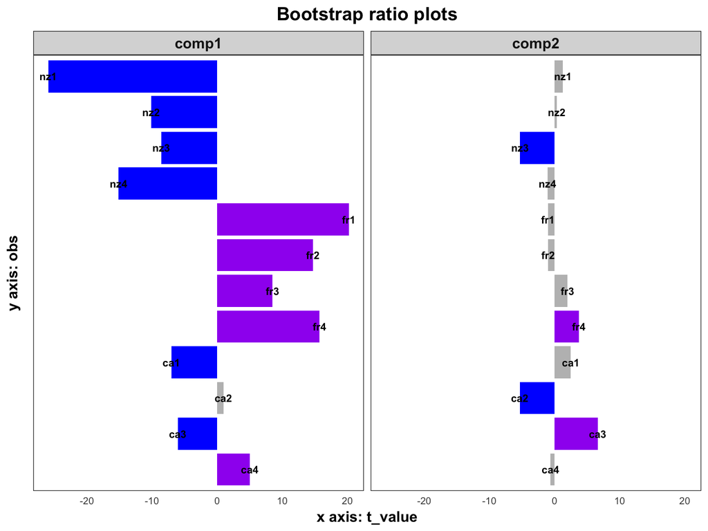

```r
plot(mfa1, type= "bootstrap", bootstrap_size = 1000, bootstrap_comps=c(1,2), facetrows=1)
```